# Risk Factor Analysis

## Outcome Variable

**Outcome Variable:** ever_stunted

## Predictor Variables

**Intervention Variable:** nchldlt5

**Adjustment Set:**

unadjusted

## Stratifying Variables

The analysis was stratified on these variable(s):

- agecat
- studyid
- country

## Data Summary

| agecat | studyid | country | A | n | nA | nAY0 | nAY1 |
| --- | --- | --- | --- | --- | --- | --- | --- |
| 3 months | ki1000108-IRC | INDIA | 1 | 410 | 89 | 56 | 33 |
| 3 months | ki1000108-IRC | INDIA | 2 | 410 | 119 | 85 | 34 |
| 3 months | ki1000108-IRC | INDIA | 3+ | 410 | 202 | 139 | 63 |
| 3 months | ki1017093b-PROVIDE | BANGLADESH | 1 | 700 | 512 | 411 | 101 |
| 3 months | ki1017093b-PROVIDE | BANGLADESH | 2 | 700 | 176 | 147 | 29 |
| 3 months | ki1017093b-PROVIDE | BANGLADESH | 3+ | 700 | 12 | 12 | 0 |
| 3 months | ki1017093c-NIH-Crypto | BANGLADESH | 1 | 758 | 541 | 455 | 86 |
| 3 months | ki1017093c-NIH-Crypto | BANGLADESH | 2 | 758 | 211 | 176 | 35 |
| 3 months | ki1017093c-NIH-Crypto | BANGLADESH | 3+ | 758 | 6 | 6 | 0 |
| 3 months | ki1066203-TanzaniaChild2 | TANZANIA, UNITED REPUBLIC OF | 1 | 2382 | 1634 | 1455 | 179 |
| 3 months | ki1066203-TanzaniaChild2 | TANZANIA, UNITED REPUBLIC OF | 2 | 2382 | 669 | 610 | 59 |
| 3 months | ki1066203-TanzaniaChild2 | TANZANIA, UNITED REPUBLIC OF | 3+ | 2382 | 79 | 74 | 5 |
| 6 months | ki1000108-IRC | INDIA | 1 | 408 | 89 | 49 | 40 |
| 6 months | ki1000108-IRC | INDIA | 2 | 408 | 119 | 69 | 50 |
| 6 months | ki1000108-IRC | INDIA | 3+ | 408 | 200 | 117 | 83 |
| 6 months | ki1017093b-PROVIDE | BANGLADESH | 1 | 640 | 469 | 345 | 124 |
| 6 months | ki1017093b-PROVIDE | BANGLADESH | 2 | 640 | 161 | 124 | 37 |
| 6 months | ki1017093b-PROVIDE | BANGLADESH | 3+ | 640 | 10 | 8 | 2 |
| 6 months | ki1017093c-NIH-Crypto | BANGLADESH | 1 | 736 | 523 | 371 | 152 |
| 6 months | ki1017093c-NIH-Crypto | BANGLADESH | 2 | 736 | 207 | 133 | 74 |
| 6 months | ki1017093c-NIH-Crypto | BANGLADESH | 3+ | 736 | 6 | 6 | 0 |
| 6 months | ki1066203-TanzaniaChild2 | TANZANIA, UNITED REPUBLIC OF | 1 | 2225 | 1521 | 1209 | 312 |
| 6 months | ki1066203-TanzaniaChild2 | TANZANIA, UNITED REPUBLIC OF | 2 | 2225 | 634 | 513 | 121 |
| 6 months | ki1066203-TanzaniaChild2 | TANZANIA, UNITED REPUBLIC OF | 3+ | 2225 | 70 | 58 | 12 |
| 6 months | ki1148112-LCNI-5 | MALAWI | 1 | 267 | 122 | 81 | 41 |
| 6 months | ki1148112-LCNI-5 | MALAWI | 2 | 267 | 122 | 78 | 44 |
| 6 months | ki1148112-LCNI-5 | MALAWI | 3+ | 267 | 23 | 13 | 10 |
| 12 months | ki1000108-IRC | INDIA | 1 | 408 | 89 | 43 | 46 |
| 12 months | ki1000108-IRC | INDIA | 2 | 408 | 119 | 55 | 64 |
| 12 months | ki1000108-IRC | INDIA | 3+ | 408 | 200 | 103 | 97 |
| 12 months | ki1017093b-PROVIDE | BANGLADESH | 1 | 609 | 443 | 296 | 147 |
| 12 months | ki1017093b-PROVIDE | BANGLADESH | 2 | 609 | 156 | 104 | 52 |
| 12 months | ki1017093b-PROVIDE | BANGLADESH | 3+ | 609 | 10 | 7 | 3 |
| 12 months | ki1017093c-NIH-Crypto | BANGLADESH | 1 | 729 | 519 | 332 | 187 |
| 12 months | ki1017093c-NIH-Crypto | BANGLADESH | 2 | 729 | 205 | 115 | 90 |
| 12 months | ki1017093c-NIH-Crypto | BANGLADESH | 3+ | 729 | 5 | 5 | 0 |
| 12 months | ki1066203-TanzaniaChild2 | TANZANIA, UNITED REPUBLIC OF | 1 | 1988 | 1369 | 943 | 426 |
| 12 months | ki1066203-TanzaniaChild2 | TANZANIA, UNITED REPUBLIC OF | 2 | 1988 | 555 | 371 | 184 |
| 12 months | ki1066203-TanzaniaChild2 | TANZANIA, UNITED REPUBLIC OF | 3+ | 1988 | 64 | 43 | 21 |
| 12 months | ki1148112-LCNI-5 | MALAWI | 1 | 789 | 378 | 209 | 169 |
| 12 months | ki1148112-LCNI-5 | MALAWI | 2 | 789 | 350 | 180 | 170 |
| 12 months | ki1148112-LCNI-5 | MALAWI | 3+ | 789 | 61 | 30 | 31 |
| 18 months | ki1000108-IRC | INDIA | 1 | 409 | 89 | 41 | 48 |
| 18 months | ki1000108-IRC | INDIA | 2 | 409 | 119 | 50 | 69 |
| 18 months | ki1000108-IRC | INDIA | 3+ | 409 | 201 | 88 | 113 |
| 18 months | ki1017093b-PROVIDE | BANGLADESH | 1 | 604 | 441 | 262 | 179 |
| 18 months | ki1017093b-PROVIDE | BANGLADESH | 2 | 604 | 154 | 83 | 71 |
| 18 months | ki1017093b-PROVIDE | BANGLADESH | 3+ | 604 | 9 | 7 | 2 |
| 18 months | ki1017093c-NIH-Crypto | BANGLADESH | 1 | 715 | 508 | 296 | 212 |
| 18 months | ki1017093c-NIH-Crypto | BANGLADESH | 2 | 715 | 202 | 98 | 104 |
| 18 months | ki1017093c-NIH-Crypto | BANGLADESH | 3+ | 715 | 5 | 4 | 1 |
| 18 months | ki1066203-TanzaniaChild2 | TANZANIA, UNITED REPUBLIC OF | 1 | 1448 | 1021 | 614 | 407 |
| 18 months | ki1066203-TanzaniaChild2 | TANZANIA, UNITED REPUBLIC OF | 2 | 1448 | 385 | 223 | 162 |
| 18 months | ki1066203-TanzaniaChild2 | TANZANIA, UNITED REPUBLIC OF | 3+ | 1448 | 42 | 24 | 18 |
| 18 months | ki1148112-LCNI-5 | MALAWI | 1 | 668 | 324 | 154 | 170 |
| 18 months | ki1148112-LCNI-5 | MALAWI | 2 | 668 | 286 | 120 | 166 |
| 18 months | ki1148112-LCNI-5 | MALAWI | 3+ | 668 | 58 | 25 | 33 |
| 24 months | ki1000108-IRC | INDIA | 1 | 410 | 89 | 35 | 54 |
| 24 months | ki1000108-IRC | INDIA | 2 | 410 | 119 | 42 | 77 |
| 24 months | ki1000108-IRC | INDIA | 3+ | 410 | 202 | 70 | 132 |
| 24 months | ki1017093b-PROVIDE | BANGLADESH | 1 | 582 | 423 | 224 | 199 |
| 24 months | ki1017093b-PROVIDE | BANGLADESH | 2 | 582 | 151 | 72 | 79 |
| 24 months | ki1017093b-PROVIDE | BANGLADESH | 3+ | 582 | 8 | 6 | 2 |
| 24 months | ki1017093c-NIH-Crypto | BANGLADESH | 1 | 634 | 448 | 237 | 211 |
| 24 months | ki1017093c-NIH-Crypto | BANGLADESH | 2 | 634 | 182 | 77 | 105 |
| 24 months | ki1017093c-NIH-Crypto | BANGLADESH | 3+ | 634 | 4 | 2 | 2 |
| 24 months | ki1066203-TanzaniaChild2 | TANZANIA, UNITED REPUBLIC OF | 1 | 958 | 682 | 396 | 286 |
| 24 months | ki1066203-TanzaniaChild2 | TANZANIA, UNITED REPUBLIC OF | 2 | 958 | 250 | 133 | 117 |
| 24 months | ki1066203-TanzaniaChild2 | TANZANIA, UNITED REPUBLIC OF | 3+ | 958 | 26 | 13 | 13 |
| 24 months | ki1148112-LCNI-5 | MALAWI | 1 | 715 | 345 | 123 | 222 |
| 24 months | ki1148112-LCNI-5 | MALAWI | 2 | 715 | 313 | 107 | 206 |
| 24 months | ki1148112-LCNI-5 | MALAWI | 3+ | 715 | 57 | 20 | 37 |

The following strata were considered:

- agecat: 12 months, studyid: ki1000108-IRC, country: INDIA
- agecat: 12 months, studyid: ki1017093b-PROVIDE, country: BANGLADESH
- agecat: 12 months, studyid: ki1017093c-NIH-Crypto, country: BANGLADESH
- agecat: 12 months, studyid: ki1066203-TanzaniaChild2, country: TANZANIA, UNITED REPUBLIC OF
- agecat: 12 months, studyid: ki1148112-LCNI-5, country: MALAWI
- agecat: 18 months, studyid: ki1000108-IRC, country: INDIA
- agecat: 18 months, studyid: ki1017093b-PROVIDE, country: BANGLADESH
- agecat: 18 months, studyid: ki1017093c-NIH-Crypto, country: BANGLADESH
- agecat: 18 months, studyid: ki1066203-TanzaniaChild2, country: TANZANIA, UNITED REPUBLIC OF
- agecat: 18 months, studyid: ki1148112-LCNI-5, country: MALAWI
- agecat: 24 months, studyid: ki1000108-IRC, country: INDIA
- agecat: 24 months, studyid: ki1017093b-PROVIDE, country: BANGLADESH
- agecat: 24 months, studyid: ki1017093c-NIH-Crypto, country: BANGLADESH
- agecat: 24 months, studyid: ki1066203-TanzaniaChild2, country: TANZANIA, UNITED REPUBLIC OF
- agecat: 24 months, studyid: ki1148112-LCNI-5, country: MALAWI
- agecat: 3 months, studyid: ki1000108-IRC, country: INDIA
- agecat: 3 months, studyid: ki1017093b-PROVIDE, country: BANGLADESH
- agecat: 3 months, studyid: ki1017093c-NIH-Crypto, country: BANGLADESH
- agecat: 3 months, studyid: ki1066203-TanzaniaChild2, country: TANZANIA, UNITED REPUBLIC OF
- agecat: 6 months, studyid: ki1000108-IRC, country: INDIA
- agecat: 6 months, studyid: ki1017093b-PROVIDE, country: BANGLADESH
- agecat: 6 months, studyid: ki1017093c-NIH-Crypto, country: BANGLADESH
- agecat: 6 months, studyid: ki1066203-TanzaniaChild2, country: TANZANIA, UNITED REPUBLIC OF
- agecat: 6 months, studyid: ki1148112-LCNI-5, country: MALAWI

### Dropped Strata

Some strata were dropped due to rare outcomes:

- agecat: 3 months, studyid: ki1017093b-PROVIDE, country: BANGLADESH
- agecat: 3 months, studyid: ki1017093c-NIH-Crypto, country: BANGLADESH
- agecat: 6 months, studyid: ki1017093b-PROVIDE, country: BANGLADESH
- agecat: 6 months, studyid: ki1017093c-NIH-Crypto, country: BANGLADESH
- agecat: 12 months, studyid: ki1017093b-PROVIDE, country: BANGLADESH
- agecat: 12 months, studyid: ki1017093c-NIH-Crypto, country: BANGLADESH
- agecat: 18 months, studyid: ki1017093b-PROVIDE, country: BANGLADESH
- agecat: 18 months, studyid: ki1017093c-NIH-Crypto, country: BANGLADESH
- agecat: 24 months, studyid: ki1017093b-PROVIDE, country: BANGLADESH
- agecat: 24 months, studyid: ki1017093c-NIH-Crypto, country: BANGLADESH

## Methods Detail

We’re interested in the causal parameters $E[Y_a]$ for all values of $a \in \mathcal{A}$. These parameters represent the mean outcome if, possibly contrary to fact, we intervened to set all units to have $A=a$. Under the randomization and positivity assumptions, these are identified by the statistical parameters $\psi_a=E_W[E_{Y|A,W}(Y|A=a,W)]$. In addition, we’re interested in the mean of $Y$, $E[Y]$ under no intervention (the observed mean). We will estimate these parameters by using SuperLearner to fit the relevant likelihood factors – $E_{Y|A,W}(Y|A=a,W)$ and $p(A=a|W)$, and then updating our likelihood fit using a joint TMLE.

For unadjusted analyses ($W=\{\}$), initial likelihoods were estimated using Lrnr_glm to estimate the simple $E(Y|A)$ and Lrnr_mean to estimate $p(A)$. For adjusted analyses, a small library containing Lrnr_glmnet, Lrnr_xgboost, and Lrnr_mean was used.

Having estimated these parameters, we will then use the delta method to estimate relative risks and attributable risks relative to a prespecified baseline level of $A$.

# Results Detail

## Results Plots

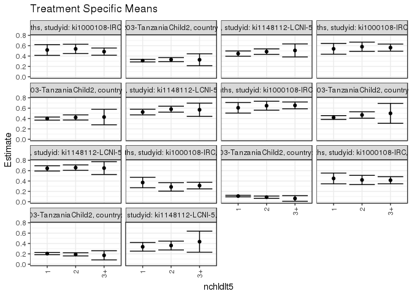

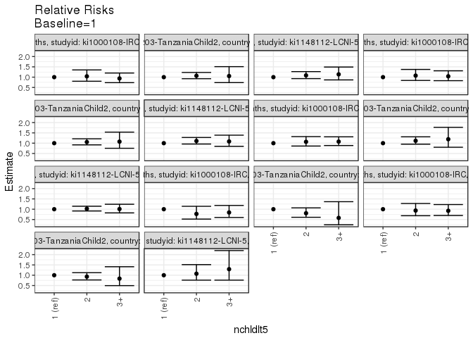

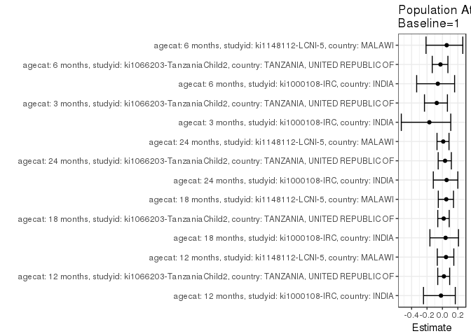

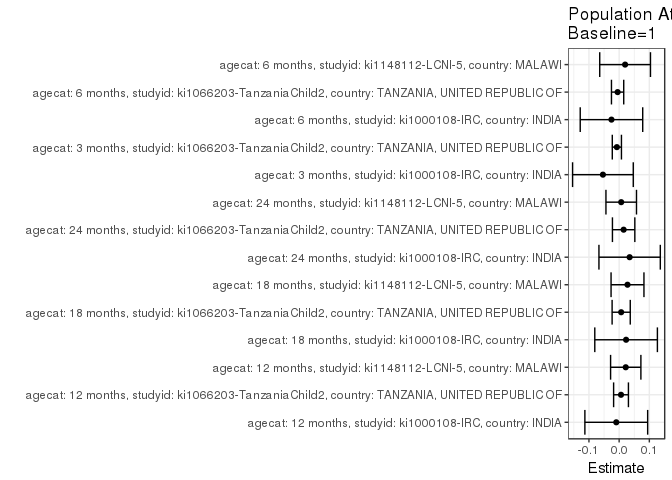

## Results Table

### Parameter: TSM

| agecat | studyid | country | intervention_level | baseline_level | estimate | ci_lower | ci_upper |
| --- | --- | --- | --- | --- | --- | --- | --- |
| 3 months | ki1000108-IRC | INDIA | 1 | NA | 0.3707865 | 0.2703147 | 0.4712584 |
| 3 months | ki1000108-IRC | INDIA | 2 | NA | 0.2857143 | 0.2044487 | 0.3669799 |
| 3 months | ki1000108-IRC | INDIA | 3+ | NA | 0.3118812 | 0.2479182 | 0.3758442 |
| 3 months | ki1066203-TanzaniaChild2 | TANZANIA, UNITED REPUBLIC OF | 1 | NA | 0.1095471 | 0.0944004 | 0.1246939 |
| 3 months | ki1066203-TanzaniaChild2 | TANZANIA, UNITED REPUBLIC OF | 2 | NA | 0.0881913 | 0.0666986 | 0.1096840 |
| 3 months | ki1066203-TanzaniaChild2 | TANZANIA, UNITED REPUBLIC OF | 3+ | NA | 0.0632911 | 0.0095880 | 0.1169943 |
| 6 months | ki1000108-IRC | INDIA | 1 | NA | 0.4494382 | 0.3459659 | 0.5529105 |
| 6 months | ki1000108-IRC | INDIA | 2 | NA | 0.4201681 | 0.3313768 | 0.5089593 |
| 6 months | ki1000108-IRC | INDIA | 3+ | NA | 0.4150000 | 0.3466296 | 0.4833704 |
| 6 months | ki1066203-TanzaniaChild2 | TANZANIA, UNITED REPUBLIC OF | 1 | NA | 0.2051282 | 0.1848307 | 0.2254257 |
| 6 months | ki1066203-TanzaniaChild2 | TANZANIA, UNITED REPUBLIC OF | 2 | NA | 0.1908517 | 0.1602558 | 0.2214476 |
| 6 months | ki1066203-TanzaniaChild2 | TANZANIA, UNITED REPUBLIC OF | 3+ | NA | 0.1714286 | 0.0831199 | 0.2597372 |
| 6 months | ki1148112-LCNI-5 | MALAWI | 1 | NA | 0.3360656 | 0.2520891 | 0.4200420 |
| 6 months | ki1148112-LCNI-5 | MALAWI | 2 | NA | 0.3606557 | 0.2752874 | 0.4460241 |
| 6 months | ki1148112-LCNI-5 | MALAWI | 3+ | NA | 0.4347826 | 0.2318075 | 0.6377577 |
| 12 months | ki1000108-IRC | INDIA | 1 | NA | 0.5168539 | 0.4129076 | 0.6208002 |
| 12 months | ki1000108-IRC | INDIA | 2 | NA | 0.5378151 | 0.4481276 | 0.6275026 |
| 12 months | ki1000108-IRC | INDIA | 3+ | NA | 0.4850000 | 0.4156510 | 0.5543490 |
| 12 months | ki1066203-TanzaniaChild2 | TANZANIA, UNITED REPUBLIC OF | 1 | NA | 0.3111760 | 0.2866452 | 0.3357069 |
| 12 months | ki1066203-TanzaniaChild2 | TANZANIA, UNITED REPUBLIC OF | 2 | NA | 0.3315315 | 0.2923561 | 0.3707070 |
| 12 months | ki1066203-TanzaniaChild2 | TANZANIA, UNITED REPUBLIC OF | 3+ | NA | 0.3281250 | 0.2130632 | 0.4431868 |
| 12 months | ki1148112-LCNI-5 | MALAWI | 1 | NA | 0.4470899 | 0.3969363 | 0.4972436 |
| 12 months | ki1148112-LCNI-5 | MALAWI | 2 | NA | 0.4857143 | 0.4333202 | 0.5381084 |
| 12 months | ki1148112-LCNI-5 | MALAWI | 3+ | NA | 0.5081967 | 0.3826602 | 0.6337333 |
| 18 months | ki1000108-IRC | INDIA | 1 | NA | 0.5393258 | 0.4356429 | 0.6430088 |
| 18 months | ki1000108-IRC | INDIA | 2 | NA | 0.5798319 | 0.4910410 | 0.6686229 |
| 18 months | ki1000108-IRC | INDIA | 3+ | NA | 0.5621891 | 0.4935192 | 0.6308589 |
| 18 months | ki1066203-TanzaniaChild2 | TANZANIA, UNITED REPUBLIC OF | 1 | NA | 0.3986288 | 0.3685860 | 0.4286716 |
| 18 months | ki1066203-TanzaniaChild2 | TANZANIA, UNITED REPUBLIC OF | 2 | NA | 0.4207792 | 0.3714486 | 0.4701099 |
| 18 months | ki1066203-TanzaniaChild2 | TANZANIA, UNITED REPUBLIC OF | 3+ | NA | 0.4285714 | 0.2788562 | 0.5782867 |
| 18 months | ki1148112-LCNI-5 | MALAWI | 1 | NA | 0.5246914 | 0.4702736 | 0.5791091 |
| 18 months | ki1148112-LCNI-5 | MALAWI | 2 | NA | 0.5804196 | 0.5231836 | 0.6376555 |
| 18 months | ki1148112-LCNI-5 | MALAWI | 3+ | NA | 0.5689655 | 0.4414220 | 0.6965090 |
| 24 months | ki1000108-IRC | INDIA | 1 | NA | 0.6067416 | 0.5051344 | 0.7083487 |
| 24 months | ki1000108-IRC | INDIA | 2 | NA | 0.6470588 | 0.5610926 | 0.7330251 |
| 24 months | ki1000108-IRC | INDIA | 3+ | NA | 0.6534653 | 0.5877620 | 0.7191687 |
| 24 months | ki1066203-TanzaniaChild2 | TANZANIA, UNITED REPUBLIC OF | 1 | NA | 0.4193548 | 0.3823014 | 0.4564083 |
| 24 months | ki1066203-TanzaniaChild2 | TANZANIA, UNITED REPUBLIC OF | 2 | NA | 0.4680000 | 0.4061153 | 0.5298847 |
| 24 months | ki1066203-TanzaniaChild2 | TANZANIA, UNITED REPUBLIC OF | 3+ | NA | 0.5000000 | 0.3077093 | 0.6922907 |
| 24 months | ki1148112-LCNI-5 | MALAWI | 1 | NA | 0.6434783 | 0.5929013 | 0.6940552 |
| 24 months | ki1148112-LCNI-5 | MALAWI | 2 | NA | 0.6581470 | 0.6055621 | 0.7107319 |
| 24 months | ki1148112-LCNI-5 | MALAWI | 3+ | NA | 0.6491228 | 0.5251417 | 0.7731039 |

### Parameter: E(Y)

| agecat | studyid | country | intervention_level | baseline_level | estimate | ci_lower | ci_upper |
| --- | --- | --- | --- | --- | --- | --- | --- |
| 3 months | ki1000108-IRC | INDIA | NA | NA | 0.3170732 | 0.3141257 | 0.3200207 |
| 3 months | ki1066203-TanzaniaChild2 | TANZANIA, UNITED REPUBLIC OF | NA | NA | 0.1020151 | 0.1015359 | 0.1024943 |
| 6 months | ki1000108-IRC | INDIA | NA | NA | 0.4240196 | 0.4226977 | 0.4253415 |
| 6 months | ki1066203-TanzaniaChild2 | TANZANIA, UNITED REPUBLIC OF | NA | NA | 0.2000000 | 0.1996585 | 0.2003415 |
| 6 months | ki1148112-LCNI-5 | MALAWI | NA | NA | 0.3558052 | 0.3525670 | 0.3590435 |
| 12 months | ki1000108-IRC | INDIA | NA | NA | 0.5073529 | 0.5051052 | 0.5096006 |
| 12 months | ki1066203-TanzaniaChild2 | TANZANIA, UNITED REPUBLIC OF | NA | NA | 0.3174044 | 0.3169964 | 0.3178125 |
| 12 months | ki1148112-LCNI-5 | MALAWI | NA | NA | 0.4689480 | 0.4674300 | 0.4704660 |
| 18 months | ki1000108-IRC | INDIA | NA | NA | 0.5623472 | 0.5609603 | 0.5637341 |
| 18 months | ki1066203-TanzaniaChild2 | TANZANIA, UNITED REPUBLIC OF | NA | NA | 0.4053867 | 0.4048444 | 0.4059291 |
| 18 months | ki1148112-LCNI-5 | MALAWI | NA | NA | 0.5523952 | 0.5503415 | 0.5544489 |
| 24 months | ki1000108-IRC | INDIA | NA | NA | 0.6414634 | 0.6396718 | 0.6432550 |
| 24 months | ki1066203-TanzaniaChild2 | TANZANIA, UNITED REPUBLIC OF | NA | NA | 0.4342380 | 0.4327220 | 0.4357540 |
| 24 months | ki1148112-LCNI-5 | MALAWI | NA | NA | 0.6503497 | 0.6498335 | 0.6508658 |

### Parameter: RR

| agecat | studyid | country | intervention_level | baseline_level | estimate | ci_lower | ci_upper |
| --- | --- | --- | --- | --- | --- | --- | --- |
| 3 months | ki1000108-IRC | INDIA | 1 | 1 | 1.0000000 | 1.0000000 | 1.000000 |
| 3 months | ki1000108-IRC | INDIA | 2 | 1 | 0.7705628 | 0.5202343 | 1.141345 |
| 3 months | ki1000108-IRC | INDIA | 3+ | 1 | 0.8411341 | 0.5987952 | 1.181550 |
| 3 months | ki1066203-TanzaniaChild2 | TANZANIA, UNITED REPUBLIC OF | 1 | 1 | 1.0000000 | 1.0000000 | 1.000000 |
| 3 months | ki1066203-TanzaniaChild2 | TANZANIA, UNITED REPUBLIC OF | 2 | 1 | 0.8050538 | 0.6083271 | 1.065400 |
| 3 months | ki1066203-TanzaniaChild2 | TANZANIA, UNITED REPUBLIC OF | 3+ | 1 | 0.5777526 | 0.2445561 | 1.364914 |
| 6 months | ki1000108-IRC | INDIA | 1 | 1 | 1.0000000 | 1.0000000 | 1.000000 |
| 6 months | ki1000108-IRC | INDIA | 2 | 1 | 0.9348739 | 0.6839628 | 1.277832 |
| 6 months | ki1000108-IRC | INDIA | 3+ | 1 | 0.9233750 | 0.6957115 | 1.225539 |
| 6 months | ki1066203-TanzaniaChild2 | TANZANIA, UNITED REPUBLIC OF | 1 | 1 | 1.0000000 | 1.0000000 | 1.000000 |
| 6 months | ki1066203-TanzaniaChild2 | TANZANIA, UNITED REPUBLIC OF | 2 | 1 | 0.9304022 | 0.7706435 | 1.123280 |
| 6 months | ki1066203-TanzaniaChild2 | TANZANIA, UNITED REPUBLIC OF | 3+ | 1 | 0.8357143 | 0.4945932 | 1.412107 |
| 6 months | ki1148112-LCNI-5 | MALAWI | 1 | 1 | 1.0000000 | 1.0000000 | 1.000000 |
| 6 months | ki1148112-LCNI-5 | MALAWI | 2 | 1 | 1.0731707 | 0.7606548 | 1.514084 |
| 6 months | ki1148112-LCNI-5 | MALAWI | 3+ | 1 | 1.2937434 | 0.7618756 | 2.196910 |
| 12 months | ki1000108-IRC | INDIA | 1 | 1 | 1.0000000 | 1.0000000 | 1.000000 |
| 12 months | ki1000108-IRC | INDIA | 2 | 1 | 1.0405554 | 0.8013121 | 1.351228 |
| 12 months | ki1000108-IRC | INDIA | 3+ | 1 | 0.9383696 | 0.7331722 | 1.200997 |
| 12 months | ki1066203-TanzaniaChild2 | TANZANIA, UNITED REPUBLIC OF | 1 | 1 | 1.0000000 | 1.0000000 | 1.000000 |
| 12 months | ki1066203-TanzaniaChild2 | TANZANIA, UNITED REPUBLIC OF | 2 | 1 | 1.0654147 | 0.9243323 | 1.228031 |
| 12 months | ki1066203-TanzaniaChild2 | TANZANIA, UNITED REPUBLIC OF | 3+ | 1 | 1.0544674 | 0.7361063 | 1.510518 |
| 12 months | ki1148112-LCNI-5 | MALAWI | 1 | 1 | 1.0000000 | 1.0000000 | 1.000000 |
| 12 months | ki1148112-LCNI-5 | MALAWI | 2 | 1 | 1.0863905 | 0.9298179 | 1.269329 |
| 12 months | ki1148112-LCNI-5 | MALAWI | 3+ | 1 | 1.1366767 | 0.8665871 | 1.490945 |
| 18 months | ki1000108-IRC | INDIA | 1 | 1 | 1.0000000 | 1.0000000 | 1.000000 |
| 18 months | ki1000108-IRC | INDIA | 2 | 1 | 1.0751050 | 0.8408335 | 1.374649 |
| 18 months | ki1000108-IRC | INDIA | 3+ | 1 | 1.0423922 | 0.8300663 | 1.309030 |
| 18 months | ki1066203-TanzaniaChild2 | TANZANIA, UNITED REPUBLIC OF | 1 | 1 | 1.0000000 | 1.0000000 | 1.000000 |
| 18 months | ki1066203-TanzaniaChild2 | TANZANIA, UNITED REPUBLIC OF | 2 | 1 | 1.0555665 | 0.9182427 | 1.213427 |
| 18 months | ki1066203-TanzaniaChild2 | TANZANIA, UNITED REPUBLIC OF | 3+ | 1 | 1.0751141 | 0.7520549 | 1.536949 |
| 18 months | ki1148112-LCNI-5 | MALAWI | 1 | 1 | 1.0000000 | 1.0000000 | 1.000000 |
| 18 months | ki1148112-LCNI-5 | MALAWI | 2 | 1 | 1.1062114 | 0.9587068 | 1.276411 |
| 18 months | ki1148112-LCNI-5 | MALAWI | 3+ | 1 | 1.0843813 | 0.8470568 | 1.388198 |
| 24 months | ki1000108-IRC | INDIA | 1 | 1 | 1.0000000 | 1.0000000 | 1.000000 |
| 24 months | ki1000108-IRC | INDIA | 2 | 1 | 1.0664488 | 0.8611990 | 1.320616 |
| 24 months | ki1000108-IRC | INDIA | 3+ | 1 | 1.0770077 | 0.8859074 | 1.309330 |
| 24 months | ki1066203-TanzaniaChild2 | TANZANIA, UNITED REPUBLIC OF | 1 | 1 | 1.0000000 | 1.0000000 | 1.000000 |
| 24 months | ki1066203-TanzaniaChild2 | TANZANIA, UNITED REPUBLIC OF | 2 | 1 | 1.1160000 | 0.9519093 | 1.308377 |
| 24 months | ki1066203-TanzaniaChild2 | TANZANIA, UNITED REPUBLIC OF | 3+ | 1 | 1.1923077 | 0.8035544 | 1.769137 |
| 24 months | ki1148112-LCNI-5 | MALAWI | 1 | 1 | 1.0000000 | 1.0000000 | 1.000000 |
| 24 months | ki1148112-LCNI-5 | MALAWI | 2 | 1 | 1.0227960 | 0.9143530 | 1.144100 |
| 24 months | ki1148112-LCNI-5 | MALAWI | 3+ | 1 | 1.0087719 | 0.8205302 | 1.240199 |

### Parameter: PAR

| agecat | studyid | country | intervention_level | baseline_level | estimate | ci_lower | ci_upper |
| --- | --- | --- | --- | --- | --- | --- | --- |
| 3 months | ki1000108-IRC | INDIA | 1 | NA | -0.0537133 | -0.1542284 | 0.0468017 |
| 3 months | ki1066203-TanzaniaChild2 | TANZANIA, UNITED REPUBLIC OF | 1 | NA | -0.0075320 | -0.0226863 | 0.0076223 |
| 6 months | ki1000108-IRC | INDIA | 1 | NA | -0.0254186 | -0.1288993 | 0.0780621 |
| 6 months | ki1066203-TanzaniaChild2 | TANZANIA, UNITED REPUBLIC OF | 1 | NA | -0.0051282 | -0.0254286 | 0.0151722 |
| 6 months | ki1148112-LCNI-5 | MALAWI | 1 | NA | 0.0197397 | -0.0642992 | 0.1037785 |
| 12 months | ki1000108-IRC | INDIA | 1 | NA | -0.0095010 | -0.1134716 | 0.0944696 |
| 12 months | ki1066203-TanzaniaChild2 | TANZANIA, UNITED REPUBLIC OF | 1 | NA | 0.0062284 | -0.0183059 | 0.0307626 |
| 12 months | ki1148112-LCNI-5 | MALAWI | 1 | NA | 0.0218581 | -0.0283185 | 0.0720347 |
| 18 months | ki1000108-IRC | INDIA | 1 | NA | 0.0230213 | -0.0806708 | 0.1267135 |
| 18 months | ki1066203-TanzaniaChild2 | TANZANIA, UNITED REPUBLIC OF | 1 | NA | 0.0067579 | -0.0232898 | 0.0368057 |
| 18 months | ki1148112-LCNI-5 | MALAWI | 1 | NA | 0.0277039 | -0.0267527 | 0.0821604 |
| 24 months | ki1000108-IRC | INDIA | 1 | NA | 0.0347218 | -0.0669011 | 0.1363448 |
| 24 months | ki1066203-TanzaniaChild2 | TANZANIA, UNITED REPUBLIC OF | 1 | NA | 0.0148832 | -0.0222013 | 0.0519676 |
| 24 months | ki1148112-LCNI-5 | MALAWI | 1 | NA | 0.0068714 | -0.0437082 | 0.0574509 |

### Parameter: PAF

| agecat | studyid | country | intervention_level | baseline_level | estimate | ci_lower | ci_upper |
| --- | --- | --- | --- | --- | --- | --- | --- |
| 3 months | ki1000108-IRC | INDIA | 1 | NA | -0.1694036 | -0.5336075 | 0.1083085 |
| 3 months | ki1066203-TanzaniaChild2 | TANZANIA, UNITED REPUBLIC OF | 1 | NA | -0.0738323 | -0.2331606 | 0.0649103 |
| 6 months | ki1000108-IRC | INDIA | 1 | NA | -0.0599467 | -0.3343784 | 0.1580446 |
| 6 months | ki1066203-TanzaniaChild2 | TANZANIA, UNITED REPUBLIC OF | 1 | NA | -0.0256410 | -0.1323361 | 0.0710006 |
| 6 months | ki1148112-LCNI-5 | MALAWI | 1 | NA | 0.0554789 | -0.2128460 | 0.2644407 |
| 12 months | ki1000108-IRC | INDIA | 1 | NA | -0.0187266 | -0.2457225 | 0.1669061 |
| 12 months | ki1066203-TanzaniaChild2 | TANZANIA, UNITED REPUBLIC OF | 1 | NA | 0.0196229 | -0.0608021 | 0.0939504 |
| 12 months | ki1148112-LCNI-5 | MALAWI | 1 | NA | 0.0466109 | -0.0666175 | 0.1478194 |
| 18 months | ki1000108-IRC | INDIA | 1 | NA | 0.0409380 | -0.1623708 | 0.2086862 |
| 18 months | ki1066203-TanzaniaChild2 | TANZANIA, UNITED REPUBLIC OF | 1 | NA | 0.0166704 | -0.0603154 | 0.0880665 |
| 18 months | ki1148112-LCNI-5 | MALAWI | 1 | NA | 0.0501522 | -0.0537202 | 0.1437852 |
| 24 months | ki1000108-IRC | INDIA | 1 | NA | 0.0541291 | -0.1183314 | 0.1999941 |
| 24 months | ki1066203-TanzaniaChild2 | TANZANIA, UNITED REPUBLIC OF | 1 | NA | 0.0342742 | -0.0550117 | 0.1160038 |
| 24 months | ki1148112-LCNI-5 | MALAWI | 1 | NA | 0.0105657 | -0.0703454 | 0.0853604 |